# lecture4

SHOGO NAMAISAWA

2026-03-14

# 第4回

ファイルのデータ読み書き、データ整理、データプロット

## 4-1：データ読み込み

### csv形式のデータ操作

- 書き出しは、関数 write.csv( ) を用いる．指定しない限り作業ディレクトリ下に保存される
- 読み込みは，関数 read.csv( ) を用いる．指定しない限り, 作業ディレクトリにある必要がある

### デフォのairqualityをcsvファイルにして、dataディレクトリに

```r
mydata <- subset(airquality, Ozone > 90, select = -Temp)

dim(mydata)
```

```
## [1] 11  5
```

```r
# ディレクトリの確認
getwd()
```

```
## [1] "/Users/namaisawashogo/my-project/premaster/data_analysis/code"
```

```r
#書き出し
#write.csv(mydata,file = "../data/mydata.csv")

# 読み込みrow.names = 1は1列目はidだよ～ん
newfile <- read.csv(file="../data/mydata.csv", row.names = 1)

head(newfile)
```

```
##    Ozone Solar.R Wind Month Day
## 30   115     223  5.7     5  30
## 62   135     269  4.1     7   1
## 69    97     267  6.3     7   8
## 70    97     272  5.7     7   9
## 86   108     223  8.0     7  25
## 99   122     255  4.0     8   7
```

### RData 形式の操作

- データフレーム単一のデータだけではなく、その時に作成した関数や途中の計算結果なども含めて、作業の状態そのものをパッケージ化して保存・再現できる
- `save()` で.rdataの拡張子で保存するう
- `load()` で.rdataの拡張子を呼び出す

```r
mydata1 <- subset(airquality, Temp>95, select = -Ozone)
mydata2 <- subset(airquality, Temp<60, select = -Ozone)

dim(mydata1)
```

```
## [1] 2 5
```

```r
dim(mydata2)
```

```
## [1] 8 5
```

```r
# 二つのdfをひとまとめに保存
# save(mydata1, mydata2, file = "../data/mydata.rdata")

loaded_objects <- load("../data/mydata.rdata", verbose = TRUE)
```

```
## Loading objects:
##   mydata1
##   mydata2
```

```r
# または戻り値を格納して確認する
loaded_objects
```

```
## [1] "mydata1" "mydata2"
```

## 4-2：データ整理

### 気象庁の東京都の気象データもよみ

```r
#fileEncoding = "sjis"で文字コードをshift-JISでエンコード
kikou <- read.csv("../data/kikou2016.csv", fileEncoding = "sjis")

head(kikou)
```

```
##   月 日 気温 降水量 日射量 風速
## 1  1  1  7.5      0  11.80  2.6
## 2  1  2  7.3      0  11.59  1.9
## 3  1  3  9.3      0  10.77  1.4
## 4  1  4  9.2      0  11.19  1.6
## 5  1  5 10.9      0  10.57  1.8
## 6  1  6  8.9      0   4.54  1.9
```

```r
dim(kikou)
```

```
## [1] 366   6
```

```r
colnames(kikou)
```

```
## [1] "月"     "日"     "気温"   "降水量" "日射量" "風速"
```

```r
str(kikou)
```

```
## 'data.frame':    366 obs. of  6 variables:
##  $ 月    : int  1 1 1 1 1 1 1 1 1 1 ...
##  $ 日    : int  1 2 3 4 5 6 7 8 9 10 ...
##  $ 気温  : num  7.5 7.3 9.3 9.2 10.9 8.9 8.7 6.8 7.3 7.9 ...
##  $ 降水量: num  0 0 0 0 0 0 0 0 0 0 ...
##  $ 日射量: num  11.8 11.6 10.8 11.2 10.6 ...
##  $ 風速  : num  2.6 1.9 1.4 1.6 1.8 1.9 2.5 1.8 2.1 2.2 ...
```

### 基本統計量を組み込み関数で

```r
kion <- kikou$気温

mean(kion)
```

```
## [1] 16.47022
```

```r
max(kion)
```

```
## [1] 31.9
```

```r
min(kion)
```

```
## [1] 2.8
```

### 行列やdfの列ごとに統計量を取り出したいね

```r
x <- matrix(1:100, 4, 25)

x
```

```
##      [,1] [,2] [,3] [,4] [,5] [,6] [,7] [,8] [,9] [,10] [,11] [,12] [,13] [,14]
## [1,]    1    5    9   13   17   21   25   29   33    37    41    45    49    53
## [2,]    2    6   10   14   18   22   26   30   34    38    42    46    50    54
## [3,]    3    7   11   15   19   23   27   31   35    39    43    47    51    55
## [4,]    4    8   12   16   20   24   28   32   36    40    44    48    52    56
##      [,15] [,16] [,17] [,18] [,19] [,20] [,21] [,22] [,23] [,24] [,25]
## [1,]    57    61    65    69    73    77    81    85    89    93    97
## [2,]    58    62    66    70    74    78    82    86    90    94    98
## [3,]    59    63    67    71    75    79    83    87    91    95    99
## [4,]    60    64    68    72    76    80    84    88    92    96   100
```

```r
sum(x)
```

```
## [1] 5050
```

```r
# 行ごとの総和
rowSums(x)
```

```
## [1] 1225 1250 1275 1300
```

### apply()で行列計算を便利に

```
R
 apply(X, MARGIN, FUN)
```

- 引数 X にデータフレームを指定
- MARGIN には行ごとは 1 を, 列ごとの計算には 2 を指定
- 引数 FUN には求めたい統計量を計算する関数を指定
- xがベクトルなら**sapply()**なら列指定

```r
# rowSums(x)と同じ
apply(x, 1, "sum")
```

```
## [1] 1225 1250 1275 1300
```

- 気候データの例

```r
x <- subset(kikou, select = -c(月, 日))

head(x)
```

```
##   気温 降水量 日射量 風速
## 1  7.5      0  11.80  2.6
## 2  7.3      0  11.59  1.9
## 3  9.3      0  10.77  1.4
## 4  9.2      0  11.19  1.6
## 5 10.9      0  10.57  1.8
## 6  8.9      0   4.54  1.9
```

```r
colMeans(x)
```

```
##      気温    降水量    日射量      風速
## 16.470219  4.860656 12.681967  2.785246
```

```r
apply(x, 2, "mean")
```

```
##      気温    降水量    日射量      風速
## 16.470219  4.860656 12.681967  2.785246
```

```r
# 引数指定なければ列指定
sapply(x, "mean")
```

```
##      気温    降水量    日射量      風速
## 16.470219  4.860656 12.681967  2.785246
```

- 自作関数の適用

```r
# 列ごとの平均より多いデータの合計値
apply(x, 2, function(x) sum(x>mean(x)))
```

```
##   気温 降水量 日射量   風速
##    188     72    157    172
```

### aggregate() データフレームの各行をいくつかのグループにまとめて統計量を計算

```
R
 aggregate(x, by, FUN)
```

- 引数 x にデータフレームを指定し
- by に各行が属するグループを指定、ベクトルをリストで与える (複数可).
- 引数 FUN には求めたい統計量を計算するための関数を指定
- x がベクトルの場合には関数 tapply( ) も利用可能

```r
kikou <- read.csv("../data/kikou2016.csv", fileEncoding ="sjis")

head(kikou)
```

```
##   月 日 気温 降水量 日射量 風速
## 1  1  1  7.5      0  11.80  2.6
## 2  1  2  7.3      0  11.59  1.9
## 3  1  3  9.3      0  10.77  1.4
## 4  1  4  9.2      0  11.19  1.6
## 5  1  5 10.9      0  10.57  1.8
## 6  1  6  8.9      0   4.54  1.9
```

### 実行例

```r
# 1-2列目以外のすべての行を月ごとのグループに分けて、平均を求める
# やっているは月ごとの平均気温とか風速をもとめてる
aggregate(kikou[ , -(1:2)], by = list(月 = kikou$月), FUN = "mean")
```

```
##    月      気温    降水量    日射量     風速
## 1   1  6.080645  2.741935  9.891290 2.393548
## 2   2  7.227586  1.965517 11.431034 2.889655
## 3   3 10.141935  3.322581 13.443226 2.812903
## 4   4 15.446667  4.000000 14.909667 3.263333
## 5   5 20.161290  4.435484 19.268065 3.383871
## 6   6 22.353333  5.816667 14.974000 2.926667
## 7   7 25.374194  2.629032 15.326129 2.674194
## 8   8 27.116129 13.354839 15.801935 3.096774
## 9   9 24.400000  9.566667 10.021000 2.436667
## 10 10 18.722581  3.112903  9.597742 2.441935
## 11 11 11.406667  4.633333  8.243000 2.466667
## 12 12  8.864516  2.709677  9.112581 2.641935
```

```r
# やっているのは１個上と同じだっけどこういうのもあるよね
aggregate( . ~月, data = subset(kikou, select = -日), FUN = "mean")
```

```
##    月      気温    降水量    日射量     風速
## 1   1  6.080645  2.741935  9.891290 2.393548
## 2   2  7.227586  1.965517 11.431034 2.889655
## 3   3 10.141935  3.322581 13.443226 2.812903
## 4   4 15.446667  4.000000 14.909667 3.263333
## 5   5 20.161290  4.435484 19.268065 3.383871
## 6   6 22.353333  5.816667 14.974000 2.926667
## 7   7 25.374194  2.629032 15.326129 2.674194
## 8   8 27.116129 13.354839 15.801935 3.096774
## 9   9 24.400000  9.566667 10.021000 2.436667
## 10 10 18.722581  3.112903  9.597742 2.441935
## 11 11 11.406667  4.633333  8.243000 2.466667
## 12 12  8.864516  2.709677  9.112581 2.641935
```

### グループを二段階

- 月と降水の有無に依るグルーピング(12*2)

```r
aggregate(kikou[ , -(1:2)], FUN = "mean", by = list(月 = kikou$月, 降水の有無 = (kikou$降水量 > 0)))
```

```
##    月 降水の有無      気温    降水量    日射量     風速
## 1   1      FALSE  6.340741  0.000000 10.809259 2.351852
## 2   2      FALSE  6.747619  0.000000 12.790000 2.804762
## 3   3      FALSE  9.781818  0.000000 15.214091 2.654545
## 4   4      FALSE 16.041176  0.000000 20.606471 3.400000
## 5   5      FALSE 20.495652  0.000000 22.570870 3.260870
## 6   6      FALSE 22.550000  0.000000 21.742143 3.328571
## 7   7      FALSE 25.838095  0.000000 17.782857 2.700000
## 8   8      FALSE 28.000000  0.000000 20.305000 3.068750
## 9   9      FALSE 25.662500  0.000000 13.544375 2.462500
## 10 10      FALSE 18.761905  0.000000 11.958095 2.461905
## 11 11      FALSE 11.829412  0.000000 10.241176 2.411765
## 12 12      FALSE  7.969565  0.000000 10.114348 2.626087
## 13  1       TRUE  4.325000 21.250000  3.695000 2.675000
## 14  2       TRUE  8.487500  7.125000  7.863750 3.112500
## 15  3       TRUE 11.022222 11.444444  9.114444 3.200000
## 16  4       TRUE 14.669231  9.230769  7.460000 3.084615
## 17  5       TRUE 19.200000 17.187500  9.772500 3.737500
## 18  6       TRUE 22.181250 10.906250  9.051875 2.575000
## 19  7       TRUE 24.400000  8.150000 10.167000 2.620000
## 20  8       TRUE 26.173333 27.600000 10.998667 3.126667
## 21  9       TRUE 22.957143 20.500000  5.994286 2.407143
## 22 10       TRUE 18.640000  9.650000  4.641000 2.400000
## 23 11       TRUE 10.853846 10.692308  5.630000 2.538462
## 24 12       TRUE 11.437500 10.500000  6.232500 2.687500
```

## 演習4.1

Rの組込データセット airquality について、月日以外の変数ごとに平均,最大値および最小値を、月ごとの平均、最大値および最小値を求めよ。ただし、NAは除去して計算する

```r
a <- airquality

colnames(a)
```

```
## [1] "Ozone"   "Solar.R" "Wind"    "Temp"    "Month"   "Day"
```

```r
apply(a, 2, "max", na.rm = TRUE)
```

```
##   Ozone Solar.R    Wind    Temp   Month     Day
##   168.0   334.0    20.7    97.0     9.0    31.0
```

```r
apply(a, 2, "min", na.rm = TRUE)
```

```
##   Ozone Solar.R    Wind    Temp   Month     Day
##     1.0     7.0     1.7    56.0     5.0     1.0
```

- 月ごとの平均、最大値および最小値

```r
aggregate(a, by = list(月 = a$Month), FUN = "max", na.rm = TRUE)
```

```
##   月 Ozone Solar.R Wind Temp Month Day
## 1  5   115     334 20.1   81     5  31
## 2  6    71     332 20.7   93     6  30
## 3  7   135     314 14.9   92     7  31
## 4  8   168     273 15.5   97     8  31
## 5  9    96     259 16.6   93     9  30
```

```r
aggregate(a, by = list(月 = a$Month), FUN = "min", na.rm = TRUE)
```

```
##   月 Ozone Solar.R Wind Temp Month Day
## 1  5     1       8  5.7   56     5   1
## 2  6    12      31  1.7   65     6   1
## 3  7     7       7  4.1   73     7   1
## 4  8     9      24  2.3   72     8   1
## 5  9     7      14  2.8   63     9   1
```

```r
aggregate(a, by = list(月 = a$Month), FUN = "mean", na.rm = TRUE)
```

```
##   月    Ozone  Solar.R      Wind     Temp Month  Day
## 1  5 23.61538 181.2963 11.622581 65.54839     5 16.0
## 2  6 29.44444 190.1667 10.266667 79.10000     6 15.5
## 3  7 59.11538 216.4839  8.941935 83.90323     7 16.0
## 4  8 59.96154 171.8571  8.793548 83.96774     8 16.0
## 5  9 31.44828 167.4333 10.180000 76.90000     9 15.5
```

## 4-3 : データプロット

### 基本書式 (ベクトルの描画)

```
R
 plot(x, type = "p", xlim = NULL, ylim = NULL, main =NULL, xlab = NULL, ylab = NULL, ...)
```

- x: ベクトル
- type: 描画タイプ. デフォルトは”p” (点プロット). 他に”l” (折れ線プロット) などがある
- xlim: x 軸の範囲. デフォルトでは自動的に決定
- ylim: y 軸の範囲. デフォルトでは自動的に決定
- main: 図のタイトル. デフォルトではなし
- xlab: x 軸のラベル名. デフォルトでは Index となる
- ylab: y 軸のラベル名. デフォルトでは x のオブジェクト名
- 他のオプション. 詳細は help(par) 参照

### ベクトルのプロット

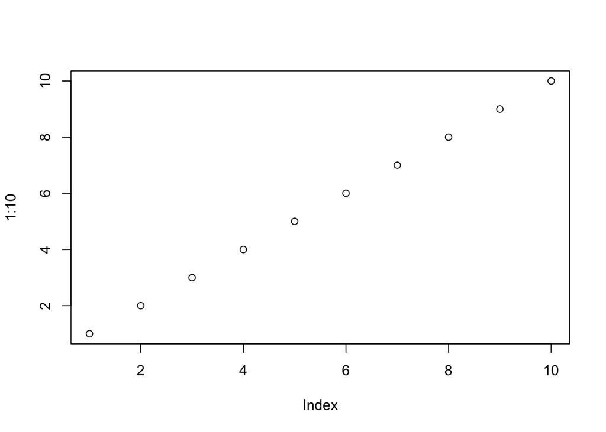

```r
plot(1:10)
```

### 疑似データの作成

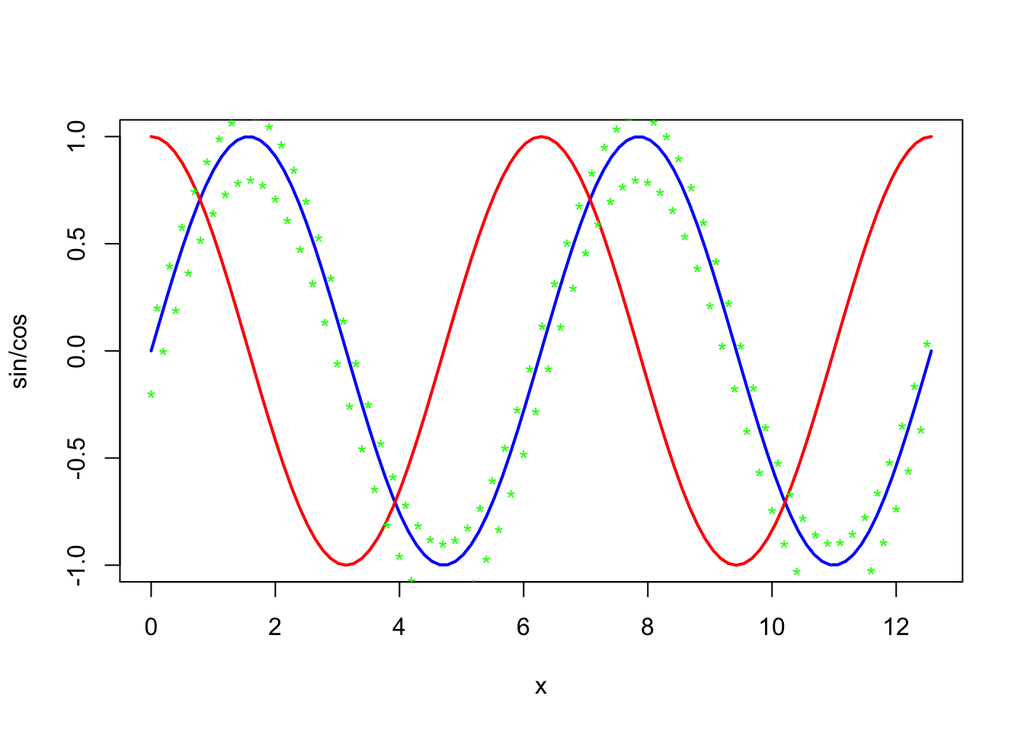

```r
# 0から4pi（周期2回分の波に相当）までの連続した数値を、0.1刻みで生成して変数xに格納
x <- seq(0,4*pi, by=0.1)
# 第1引数のデータ（今回は-0.2と0.1）を、第2引数で指定した長さ（今回はxの要素数）になるまで繰り返し
y <- sin(x) + rep_len(c(-0.2, 0.1), length(x))

plot(sin, 0, 4*pi,
     col="blue",
     lwd=2,
     ylab = "sin/cos")
curve(cos,
      add = TRUE,
      col="red",
      lwd=2)
points(x,y,col="green",pch="*")
```

### (x,y)データの描画

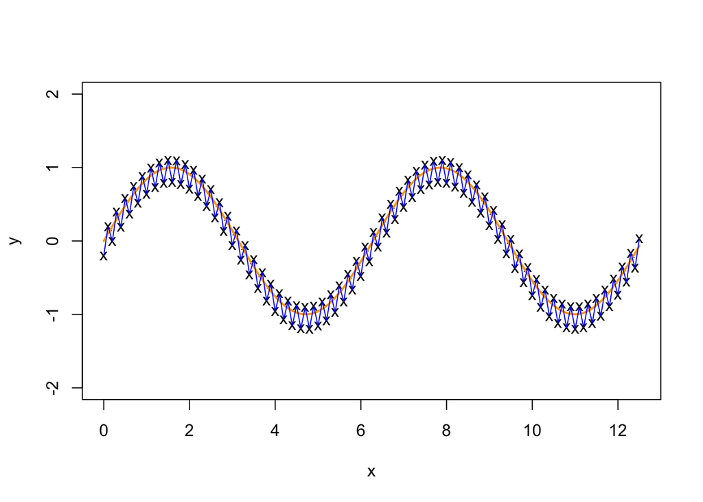

```r
plot(x,y,type="p",pch="x",ylim=c(-2,2))
curve(sin, add=TRUE, col="orange",lwd=2)
lines(x,y,col="blue")
```

### 読み込んだdfを用いて

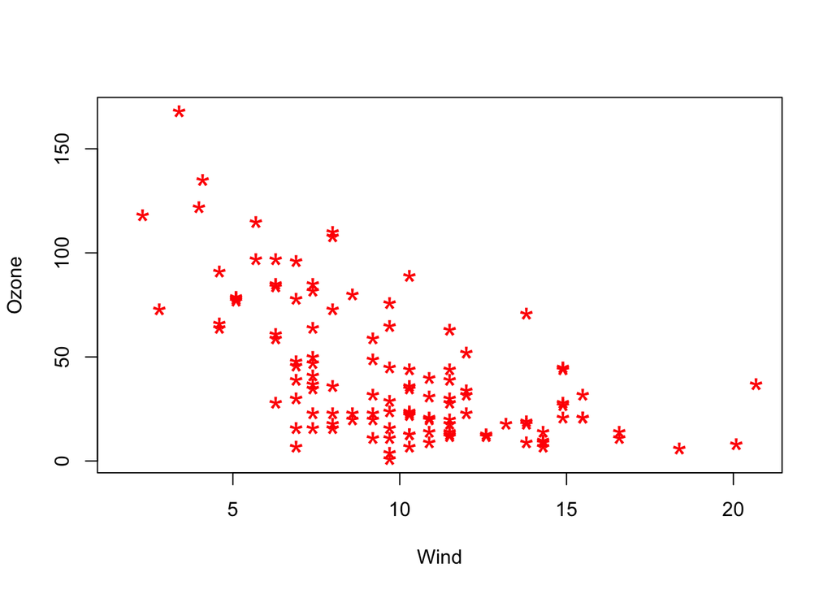

```r
plot(Ozone ~ Wind, data=airquality, pch = "*", col="red",cex=2)
```

### 演習4.2

Rの組込データセット sleep データ (睡眠薬投与による睡眠時間の増減のデータ・詳細は help(sleep) 参照)において, group が1のデータの extra を×軸, group が2のデータのextraをy軸とした散布図を描画せよ、ただし、点の色は青,点の形は×とし、タイトルを Sleep data, × 軸のラベルを group 1, y 軸のラベルを group 2とせよ(適宜インターネット上の情報を参照せよ、また、x軸, y 軸のデータはそれぞれ以下としてつくるとよい

```
R
 x <- subset (sleep, group 1, extra, drop = TRUE)
 y <- subset (sleep, group == 2, extra, drop = TRUE)
```

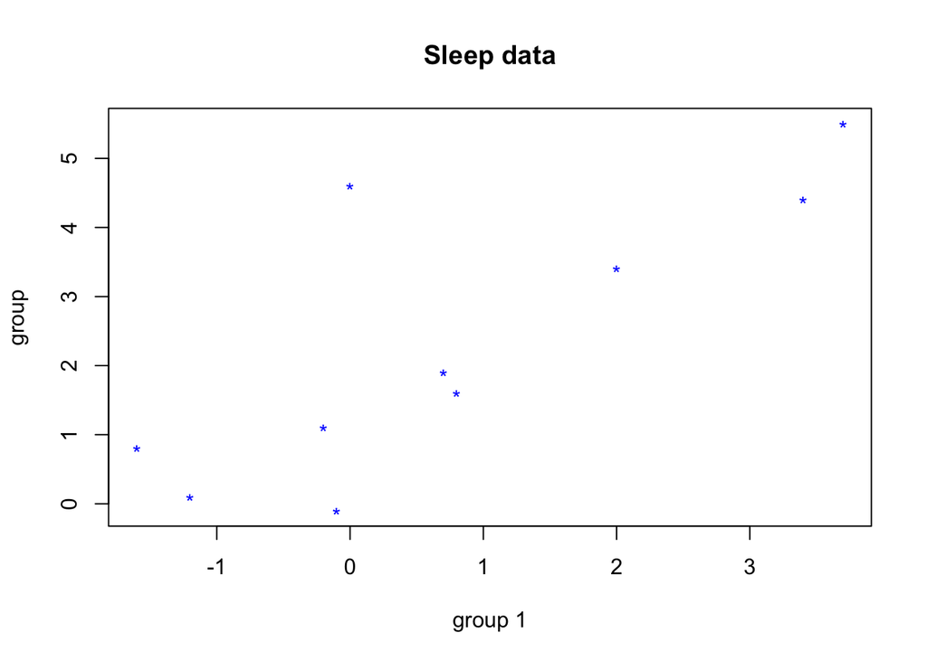

```r
x <- subset (sleep, group == 1, extra, drop = TRUE)
y <- subset (sleep, group == 2, extra, drop = TRUE)

plot(x,y,
     col="blue",
     pch="*",
     main="Sleep data",
     xlab="group 1",
     ylab="group")
```

### legend()で凡例を追加

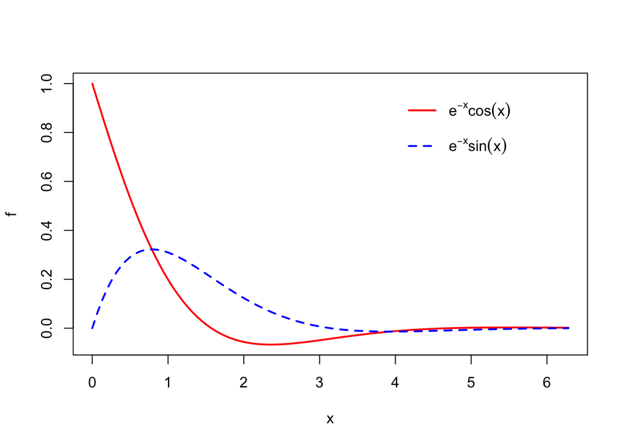

```r
f <- function(x) exp(-x)*cos(x)
plot(f, 0,2*pi,
     col="red",
     lwd=2)

g <- function(x) exp(-x)*sin(x)
curve(g, lty=2, #点線グラフに指定
      add=TRUE,
      col="blue",
      lwd=2)
legend(4,1, # (4,1)の
       legend=c(expression(e^{-x}*cos(x), e^{-x}*sin(x))), # 凡例
       lty = c(1,2), lwd=2, col = c("red", "blue"),
       bty="n",
       y.intersp = 2 #行間
       )
```